# Tutorial: Approximate Methods

In this notebook, you'll practice using some of the approximate methods covered in the notes. To make it as straightforward as possible, we'll start with a couple of examples where you either already have a solution via MCMC, or where there is an analytic solution, before letting you loose on a case where you won't have a correct answer to compare to.

For each case, you will

- carry out the Laplace Approximation,
- choose summary statistics,
- implement the simplest possible version of Approximate Bayes, and
- (where possible) compare to the exact or MCMC posteriors

```python
# !pip install incredible

from yaml import safe_load
from numdifftools import Hessian
import numpy as np
from scipy.optimize import minimize
import scipy.stats as st
import statsmodels.api as sm
import matplotlib.pyplot as plt
%matplotlib inline

import incredible as cr
```

```python
thisTutorial = 'approximate_methods'

## Set the variable `datapath` to the path to the data for this tutorial.

## If you are working in Colab, it will be something like:
#from google.colab import drive
#drive.mount('/content/drive')
#datapath = '/content/drive/MyDrive/Physics267_data/' + thisTutorial + '/'

## Otherwise, it can be an absolute path or relative to the current directory, as in
#datapath = '../../data/' + thisTutorial + '/'

# YOUR CODE HERE
raise NotImplementedError()
```

```python
# do not mess with the housekeeping
# Tests housekeeping
```

## Case: Cluster redshift distribution yet again

Our first example will be constraining the mean and variance of the galaxy redshifts in a cluster, for the final time. Refer to the Bayes "on a grid" and "off-grid" notebooks if you've forgotten the details of this model.

As usual, read in the data and plot a histogram:

```python
z_gal = np.loadtxt(datapath+'redshifts.txt')
z_gal
```

```
array([1.98 , 1.981, 1.983, 1.982, 1.987, 1.963, 1.993, 1.977, 1.988,
       1.966, 1.977, 1.979, 1.963, 1.996, 1.976, 1.991, 1.981, 1.962,
       1.979, 1.963, 1.972, 1.993, 1.997, 1.969, 1.971, 1.981, 1.977,
       1.963, 1.977, 1.979, 1.978, 1.972, 1.976])
```

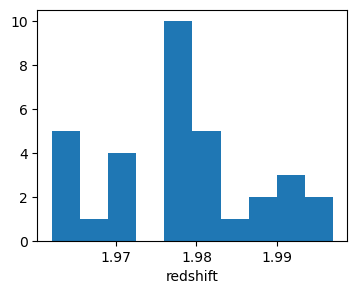

```python
plt.rcParams['figure.figsize'] = (4.0, 3.0)
plt.hist(z_gal);
plt.xlabel('redshift');
```

We will be constraining the mean and variance (as opposed to standard deviation), consistent with the "off-grid" notebook.

```python
param_names = ['mu', 'sigma2']
param_labels = [r'$\mu$', r'$\sigma^2$']
```

Copy over your definition of the priors from the "off-grid" notebook:

```python
# hyperparams = {'mu0':..., 'tau0':..., 'alpha0':..., 'beta0':...}
# YOUR CODE HERE
raise NotImplementedError()
```

```python
# hyperparameters check
# Tests test_hyper (1 point)
```

### Get a trustworthy result for comparison

Before trying out the approximate methods, we'll quickly reproduce a solution we can be confident in. You should be able to simply paste in your work from the "off-grid" notebook below.

```python
# guess = {'mu':..., 'sigma2':...}

# def conditional_post_mu(data, par, hypar):
    # data: array of measured redshifts
    # par: dictionary of parameter values (mu,sigma2 parametrization)
    # hypar: dictionary of hyperparameter values
    # returns a tuple (mean, stdev) encoding the normal distribution from which a new value of mu should be drawn

# def conditional_post_sigma2(data, par, hypar):
    # data: array of measured redshifts
    # par: dictionary of parameter values (mu,sigma2 parametrization)
    # hypar: dictionary of hyperparameter values
    # return a tuple (alpha, beta) encoding the inverse-gamma distribution from which a new value of sigma2 should be drawn

# YOUR CODE HERE
raise NotImplementedError()
```

These are the given update functions:

```python
def update_mu(data, par, hypar):
    mean,sd = conditional_post_mu(data, par, hypar)
    par['mu'] = st.norm.rvs(mean, sd)

def update_sigma2(data, par, hypar):
    alpha,beta = conditional_post_sigma2(data, par, hypar)
    par['sigma2'] = st.invgamma.rvs(alpha, scale=beta)
```

We run a quick Gibbs chain and double-check the results:

```python
%%time
params = guess.copy()
nsamples = 30000
gchain = np.zeros((nsamples, len(params)))
for i in range(nsamples):
    update_mu(z_gal, params, hyperparams)
    update_sigma2(z_gal, params, hyperparams)
    gchain[i,:] = [params[k] for k in param_names]
```

```
CPU times: user 779 ms, sys: 68.4 ms, total: 847 ms
Wall time: 783 ms
```

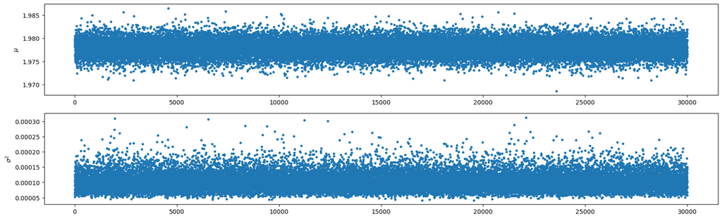

```python
fig, ax = plt.subplots(gchain.shape[1], 1, figsize=(20, gchain.shape[1]*3));
cr.plot_traces(gchain, ax, labels=param_labels);
```

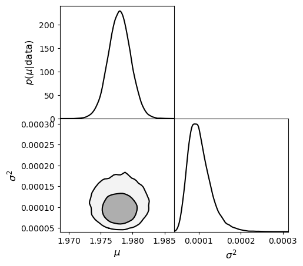

```python
gtri = cr.whist_triangle(gchain, bins=50, smooth2D=1);
cr.whist_triangle_plot(gtri, paramNames=param_labels);
```

This will save the contours above for comparison later. If your chain somehow had convergence or other issues, you'll need to address that before continuing, though it shouldn't if your previous notebook worked well.

```python
gpost = gtri[1][0]
```

### Laplace Approximation

Recall that to implement the LA, you will need to

1. find the maximum of the posterior, and
2. estimate the matrix of second derivatives of the log-posterior at that point.

We'll use `scipy.optimize.minimize`, which you've seen before, to accomplish these. First, we will need a function returning *minus* the log posterior. You should have everything you need for this from your solution to the "off grid" notebook.

```python
# def minus_lnp(params, data, hypar):
    # params: *array* of parameter values, in param_names order (because `minimize` wants an array)
    # data: array of measured redshifts
    # hypar: *dictionary* of hyperparameter values
    # returns a scalar value of -ln(posterior) (up to a constant)

# YOUR CODE HERE
raise NotImplementedError()
```

We also need a guess at the parameter values, for the minimizer to use as a starting point. Having solved this exact inference problem several times already, we are confident you can provide one. However, note that starting the minimizer *too* close to the minimum can lead to numerical issues, leading it to announce failure and not return all the information we need, so you might need to adjust your guess on that account.

```python
# guess = {'mu':..., 'sigma2':...}
# guessvec = [guess[p] for p in param_names]

# YOUR CODE HERE
raise NotImplementedError()
```

Because you would be disappointed if we forgot, let's make sure the above cells play nicely together.

```python
print(minus_lnp(guessvec, z_gal, hyperparams))
assert np.isfinite(minus_lnp(guessvec, z_gal, hyperparams))
```

```
6212.051715093479
```

```python
# this will test against our solutions
# Tests mlnp (1 point)
```

Now we turn things over to `scipy`. If you're not familiar, there are a handful of algorithms that `minimize` can use. We'd like one that internally estimates and uses the second derivatives of the function being minimized, since it means we can just get those derivatives about the minimum from the fitter instead of estimating them ourselves. The default algorithm does this, though note that this is not true of all the options, and the specific method for accessing the derivatives varies (see the documentation for `minimize` for details).

Since these algorithms will generally not be happy about infinite values, the `bounds` argument should be used to prevent `minimize` from going anywhere that the posterior probability is numerically zero. Make sure the code below is consistent with the priors we're using before running it.

```python
LA = minimize(minus_lnp, guessvec, args=(z_gal, hyperparams), bounds=((None,None),(1e-10,None)))
LA
```

```
  message: CONVERGENCE: RELATIVE REDUCTION OF F <= FACTR*EPSMCH
  success: True
   status: 0
      fun: -88.24814975554209
        x: [ 1.978e+00  8.782e-05]
      nit: 23
      jac: [ 2.392e-03  2.643e-01]
     nfev: 168
     njev: 56
 hess_inv: <2x2 LbfgsInvHessProduct with dtype=float64>
```

Note that the algorithm tells us whether it was successful, or at least whether it thinks it was. This should always be checked. If the minimizer failed, you may need to adjust the starting guess, or in the worst case try a different algorithm. In the latter case, you may also need to change the method called below to extract the inverse-Hessian (see the `minimize` documentation).

```python
# Checkpoint minimize1 1
assert LA.success
# End checkpoint
```

The posterior mode is stored in `LA.x`.

```python
LA_mode = np.array(LA.x)
LA_mode
```

```
array([1.97793709e+00, 8.78202300e-05])
```

The inverse-Hessian, which is the posterior covariance matrix of the parameters, is helpfully provided in `LA.hess_inv`. It can be accessed as shown below (note that whether the inverse is provided, and in what format, varies with the minimization method).

```python
LA_postcov = LA.hess_inv.todense()
LA_postcov
```

```
array([[ 3.92920869e-06, -2.77127128e-09],
       [-2.77127128e-09,  4.67103877e-10]])
```

In our limited experience, the covariance estimate that comes from `scipy.minimize` is hilariously wrong a decent fraction of the time. Therefore, it would be good practice to check it with an independent estimate of the Hessian. This is set up below using the `numdifftools` package. We have no special reason to believe that this will do a better job, but at least there is a `step` parameter that you can play with to see how robust the result is to the initial scale of the finite differencing. In the provided code, we set this to a small fraction of the existing standard deviation implied by `LA_postcov`, but you can and should experiment. (Hint: if you get negative values on the diagonal of the resulting covariance matrix, the step is probably too small.)

```python
info = Hessian(lambda x:minus_lnp(x, z_gal, hyperparams), step=1e-6*np.sqrt(LA_postcov.diagonal()), full_output=True)(LA_mode)
nd_hess = info.estimate
nd_postcov = np.linalg.inv(nd_hess)
print(nd_postcov,'\n')
print(info)
```

```
[[2.67143489e-06 0.00000000e+00]
 [0.00000000e+00 4.36800262e-10]]

EstimateResult(estimate=array([[3.74330666e+05, 0.00000000e+00],
       [0.00000000e+00, 2.28937592e+09]]), error_estimate=array([[2.62426504e-08, 2.74612717e-10],
       [2.51865348e-08, 6.45939210e-06]]), final_step=array([[1.98222327e-09, 2.16124896e-11],
       [1.98222327e-09, 2.16124896e-11]]), best_index=array([0, 1, 2, 3]))
```

Let's go ahead and visualize the mode and the usual 2D credible regions, including both of these LA covariance estimates.

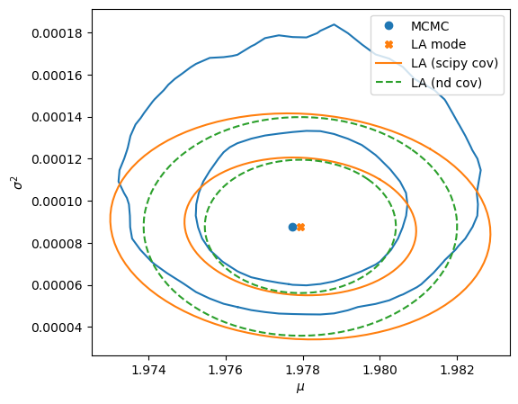

```python
# Checkpoint zgal_LA_byI 0
plt.rcParams['figure.figsize'] = (6.0, 5.0)
plt.plot(gpost['mode'][0], gpost['mode'][1], 'o', color='C0', label='MCMC');
cr.ci2D_plot(gpost, plt, Line2D_kwargs={'color':'C0'});
plt.plot(LA_mode[0], LA_mode[1], 'X', color='C1', label="LA mode");
cr.cov_ellipse(LA_postcov, center=LA_mode, level=0.68268949, plot=plt, fmt='-', color='C1', label='LA (scipy cov)');
cr.cov_ellipse(LA_postcov, center=LA_mode, level=0.95449974, plot=plt, fmt='-', color='C1');
# todo: LA with alternative cov
cr.cov_ellipse(nd_postcov, center=LA_mode, level=0.68268949, plot=plt, fmt='--', color='C2', label='LA (nd cov)');
cr.cov_ellipse(nd_postcov, center=LA_mode, level=0.95449974, plot=plt, fmt='--', color='C2');
plt.xlabel(param_labels[0]);
plt.ylabel(param_labels[1]);
plt.legend(loc=1);
# End checkpoint
```

### Approximate Bayesian Computation

Next, we turn to ABC. Below, you'll implement the simplest version of this algorithm:

1. Choose a set of summary statistics that encode important features of the data.
2. Choose a distance function providing a metric for comparing summary statistics computed from different data, and a distance threshold.
3. For many iterations,
- sample a set of parameters from the prior;
- simulate a mock data set from those parameters using the generative model;
- compute the summary statistics from those mock data;
- if the distance between that summary and the summary statistics computed on the real data is smaller than the threshold, accept the parameter sample.

Needless to say, this is not the most efficient version of ABC, but it will serve for this exercise. However, there is an immediate, practical issue, namely that we are often in the habit of adopting priors that are much broader than the posterior. If the priors are improper, we don't even have a way to draw from them, but in any case we might expect this naive implementation can be expected to take an exceptionally long time to produce even a single acceptable sample if the priors are very wide. (This is a good argument for choosing sensible priors, if you needed another one.)

We will inelegantly work around this issue by remembering that, for parameter estimation, we only really need to consider the prior over the region of parameter space where the posterior will be non-tiny. Seeing how we have an approximate posterior from LA, let's use it to sneakily redefine the functional bounds of the priors for this exercise. Truncating the priors, $p(\mu)$ and $p(\sigma^2)$, at the 0.0001 and 0.9999 quantiles of their respective marginalized posteriors from LA seems to work well in this case, but you can and should make adjustments as needed to capture the whole posterior distribution.

To make it simpler to try out different summary statistics or distance metrics, we'll use classes and inheritance to package up reusable code. The cell below has just one method for you to complete, namely the `run` method that performs the loop in the pseudocode above. **Do not** include an accept/reject step here (that is, accept all samples); instead, record the distance for each sample. That way, we can easily look at how the choice of distance threshold affects our results later.

Also, try to make your code general enough that we can reuse it with another generative model and data set later on; that is, don't reference variables at global scope if they're stored in the `ABC` object already by its constructor.

> If you are not too familiar with classes in Python, here is an extremely brief overview. A `class` defines a structure for holding potentially diverse data, as well as functions that can act on them. Each instance of a class has its own data independent of any other, and the data can be accessed as in `obj.thing`, where `obj` is an instance of the class. Instances are created by "calling" the name of the class, as in `obj = MyClass()`. The class definition includes all of the related functions, which conventionally have `self` as their first argument; this is automatically filled in with the instance that the function is called on. E.g., if a class definition includes `def func(self, x)`, we would call `func` on the instance `obj` like this: `obj.func(x)`. Within `func` all the data that `obj` owns can be accessed as in `self.thing`, since within the function call `self` has the value `obj`. The special function `__init__` is called when an instance is created, and it is allowed to have arguments in addition to `self`, as below. Variables at global scope are available within these functions, although it's considered good practice for anything that's needed to be stored in the object or passed as an argument. If that didn't make enough sense, the provided code below hopefully will help.

```python
class ABC:
    def __init__(self, data, param_names, priors):
        # This is meant to be very generic - `data` and `priors` can be anything you define to package up the data
        # and prior information. `param_names` is our usual list of strings (for plot labeling).
        self.data = data
        self.s_true = self.summaries(data)
        self.priors = priors
        self.param_names = param_names
    # derived classes must define the following
    def summaries(self, data):
        # return summary statistics as a 1D np.array
        raise Exception('ABC::summaries should be defined by a deriving class')
    def distance(self, s1, s2):
        # return scalar distance between 2 sets of summary statistics
        raise Exception('ABC::distance should be defined by a deriving class')
    def simulate(self, someParameter1=0.0, someParameter2=0.0):
        # return simulated data, given additional parameters arguments
        raise Exception('ABC::simulate should be defined by a deriving class')
    # the important part
    def run(self, Nsim):
        # Nsim is the number of mock data sets to generate and use
        # Returns nothing, but stores results in the following arrays:
        self.samples = np.full((Nsim, len(self.param_names)), np.nan) # Nsim x Nparameters array of samples
        self.distances = np.full(Nsim, np.nan) # length-Nsim array of "distances" between real and mock data
        #
        for i in range(Nsim):
            # draw parameters from the prior
            # simulate mock data from those parameters
            # compute summaries and their distance from self.s_true
            # store parameters in the ith row of self.samples
            # store distance in the ith entry of self.distances
            # YOUR CODE HERE
            raise NotImplementedError()
    # useful visualizations
    def distance_hist(self):
        plt.rcParams['figure.figsize'] = (4.0, 3.0)
        plt.hist(self.distances);
        plt.xlabel("d");
    def select_distances(self, eps):
        self.selection = np.flatnonzero(self.distances < eps)
        self.samples2 = self.samples[self.selection,:]
        print('Acceptance rate:', self.samples2.shape[0]/self.samples.shape[0], '(', self.samples2.shape[0], 'accepted samples )')
    def plot_acceptances(self, truth=None, truth_tri=None, size=8.0, show_rejects=True):
        plt.rcParams['figure.figsize'] = (size, size)
        n = len(self.param_names)
        fig = plt.figure()
        axes = []
        for i,p in enumerate(self.param_names):
            axes.append([])
            ax = fig.add_subplot(n, n, (i*n)+i+1)
            ax0 = ax
            ax.hist(self.samples2[:,i], density=True, label='ABC');
            if truth is not None:
                aa = np.linspace(*self.priors[p].ppf([0.0001,0.9999]), 100)
                ax.plot(aa, truth['1D'][p].pdf(aa), label='truth');
            if i==n-1:
                ax.set_xlabel(p);
            else:
                ax.get_xaxis().set_ticklabels([])
            ax.get_yaxis().set_ticklabels([])
            for j,q in enumerate(self.param_names):
                if j == i:
                    break
                ax = fig.add_subplot(n, n, (i*n)+j+1)
                axes[-1].append(ax)
                if show_rejects:
                    ax.plot(self.samples[:,j], self.samples[:,i], ',', color='C2');
                ax.plot(self.samples2[:,j], self.samples2[:,i], '.');
                if truth is not None:
                    for k in truth['2D'].keys():
                        ax.plot(truth['2D'][k][0], truth['2D'][k][1], color='C1', label='truth');
                if i==n-1:
                    ax.set_xlabel(q);
                else:
                    ax.get_xaxis().set_ticklabels([])
                if j==0:
                    ax.set_ylabel(p);
                else:
                    ax.get_yaxis().set_ticklabels([])
            axes[-1].append(ax0)
        if truth_tri is not None:
             cr.whist_triangle_plot(truth_tri, axes=axes, linecolor1D='C1', linecolor2D='C1', fill2D=False);
```

Next, we need to choose summary statistics and a distance function. These are up to you, and while the sufficient statistics for this problem are intuitive, the very most obvious choice may not work well. It can also be fun to try various less obvious choices to see how well (or if) the algorithm works. That said, the work you turn in should be able to approximate the true posterior.

**Record your choice of summary statistic(s) and distance function in words below.**

> choice of summary statistics and distance function

```python
# Checkpoint zgal_summaries_byI 0
# Record your choice of summary statistic(s) and distance function in words above!
# End checkpoint
```

We can define a derived class of `ABC` that implements these choices by specifying just the 3 functions that were left out above.

> Another aside for those unused to classes in Python. The construction `class ABC_zgal(ABC)` below means that `ABC_zgal` will inherit from `ABC`, i.e. all functions of `ABC` are carried over to `ABC_zgal` unless we explicity redefine them. In the `ABC` definition, we had `summaries`, `distance` and `simulate` throw errors as a reminder that we do need to define them for this class to be useful, and so those are the ones that you need to provide below. Every other function that `ABC` defines will exist for `ABC_zgal` also, without us having to copy their code.

```python
# class ABC_zgal(ABC):
#    def summaries(self, data):
#        # return summary statistics as a 1D np.array
#    def distance(self, s1, s2):
#        # return scalar distance between 2 sets of summary statistics
#    def simulate(self, mu, sigma2):
#        # return simulated data, given additional parameters arguments

# YOUR CODE HERE
raise NotImplementedError()
```

Next, define a `priors` object that stores whatever information is needed to specify the prior distributions you chose above. This will be available in the `ABC.run` function for this part of the notebook.

```python
# priors = ... # However you want to encode the prior distributions; it depends you you wrote ABC.run().

# YOUR CODE HERE
raise NotImplementedError()
```

Let's create the `ABC_zgal` instance.

```python
abc = ABC_zgal(z_gal, param_names, priors)
```

Check that it doesn't crash when trying to run:

```python
abc.run(1)
print(abc.samples)
print(abc.distances)
print(abc.summaries(abc.simulate(*abc.samples[0])))
```

```
[[1.97720405e+00 5.23984945e-05]]
[0.00252913]
[1.97781029 0.00804924]
```

If not, let's produce a good number of samples and associated distances (you might want to reduce the number while in debugging mode).

```python
%time abc.run(100000)
```

```
CPU times: user 7.61 s, sys: 243 ms, total: 7.86 s
Wall time: 7.64 s
```

You might be wondering why we haven't said anything about the distance threshold for accepting samples yet. The reason is, simply, that the absolute magnitude of threshold that makes sense depends on both the choice of summary statistics (and their dimensionality) and the choice of distance function. For most sensible distance definitions, zero is the ideal in the limit of infinite samples, but it makes sense to first take a look at the distribution of distances corresponding to our simulated data sets so far (using this handy provided function!).

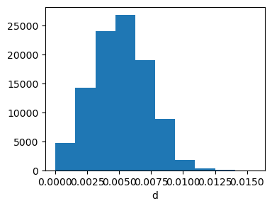

```python
abc.distance_hist();
```

Note that, even though small distances are a goal, having most of our samples "piled up" near zero distance is not necessarily a good thing. This could be an indication that the summary statistics and/or distance metric are not discriminating enough to allow us to approximate the posterior well, something we would see in the following cells.

The cells below visualize how the accepted samples change as we reduce the threshold from the median of the distribution above to the first percentile. Each one shows a "triangle" plot comparing the exact posterior (orange) to the distribution of accepted samples (blue). The rejected samples are shown in green in the off-diagonal panel, just to verify that they fill the space uniformly.

```
eps = 0.005080145721198607
Acceptance rate: 0.5 ( 50000 accepted samples )
```

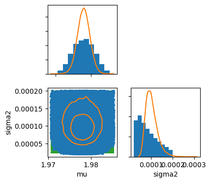

```python
eps = np.quantile(abc.distances, 0.5)
print("eps =", eps)
abc.select_distances(eps)
abc.plot_acceptances(truth_tri=gtri, size=4.0)
```

```
eps = 0.0022754214676507897
Acceptance rate: 0.1 ( 10000 accepted samples )
```

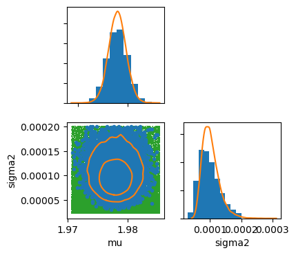

```python
eps = np.quantile(abc.distances, 0.1)
print("eps =", eps)
abc.select_distances(eps)
abc.plot_acceptances(truth_tri=gtri, size=4.0)
```

```
eps = 0.0007366678798740315
Acceptance rate: 0.01 ( 1000 accepted samples )
```

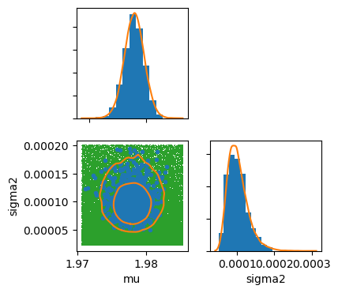

```python
eps = np.quantile(abc.distances, 0.01)
print("eps =", eps)
abc.select_distances(eps)
abc.plot_acceptances(truth_tri=gtri, size=4.0)
```

Iterate the above as needed, adjusting the tolerance and/or number of samples, until you think the approximation is acceptable, or revisiting the choice of summary statistic or distance metric if you think it's needed.

Below, we will crudely compare the ABC and MCMC distributions by checking the "centers" and "widths" of their respective 1D credible intervals. Note that these tests are a little more likely to fail for purely numerical reasons than others in this class, since they're comparing one monte carlo to another.

```python
# Checkpoint zgal_ABC 1
print('Checking that we have a non-silly number of samples left...')
assert abc.samples2.shape[0] >= 100
print('Checking credible interval for mu...')
ci = cr.whist_ci(cr.whist(abc.samples2[:,0]))
gci = gtri[0][0][1]
assert np.isclose(ci['center'][0], gci['center'][0], rtol=0.1)
assert np.isclose(ci['width'][0], gci['width'][0], rtol=0.1)
print('Checking credible interval for sigma2...')
ci = cr.whist_ci(cr.whist(abc.samples2[:,1]))
gci = gtri[1][1][1]
assert np.isclose(ci['center'][0], gci['center'][0], rtol=0.1)
assert np.isclose(ci['width'][0], gci['width'][0], rtol=0.15)
print('Yay!')
# End checkpoint
```

```
Checking that we have a non-silly number of samples left...
Checking credible interval for mu...
Checking credible interval for sigma2...
Yay!
```

```python
# this will check against our MCMC solution
# Tests zgal_ABC_hid (1 point)
```

## Case: ordinary least squares (OLS)

The classic OLS problem corresponds to the following scenario and assumptions:

- We have data in the form of a list of $(x,y)$ pairs.
- The $x$ values are fixed (we assume no uncertainty in their generation).
- Each $y_i$ is independently generated from a normal distribution with unit variance and whose mean is linear in $x$ (that is, $a + b x_i$).
- Priors on $a$ and $b$ are both uniform over the real line.

```python
param_names = ['a', 'b']
```

You may have already done it in a previous exercise, but draw the PGM and write down the generative model for this setup.

> Space for your PGM and expressions

As usual, read in your very own data set to work with, stored below as 1D `x` and `y` arrays.

```python
table = np.loadtxt(datapath+'ols.txt')
x = table[:,0]
y = table[:,1]
```

They look like this:

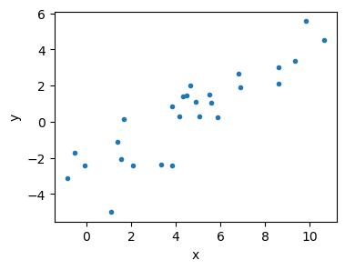

```python
plt.rcParams['figure.figsize'] = (4.0, 3.0)
plt.plot(x, y, '.');
plt.xlabel("x"); plt.ylabel("y");
```

### Find the exact solution, for comparison

As you might know, the strong assumptions in OLS make the calculation of the posterior algebraically solvable. This is convenient, as we can easily compute the exact posterior and compare our approximate results to it. The calculations are not especially hard to implement manually, but we will nevertheless let the `statsmodels` package do them for us. (Note: If you do decide to do the calculations yourself as a check, we have found that the results are not `np.close` to the `sm` results reasonably often, presumably due to accumulated floating point error. The discrepancy isn't really important here, but may throw off the automatic grader.)

```python
model = sm.OLS(y, sm.add_constant(x))
ols = model.fit()
```

The posterior, $p(a,b|x,y)$, is a 2D Gaussian with mean

```python
ols.params
```

```
array([-2.75994154,  0.69626281])
```

and covariance matrix

```python
ols.normalized_cov_params
```

```
array([[ 0.11651851, -0.01751249],
       [-0.01751249,  0.0038586 ]])
```

Codify this by storing frozen `st.norm` objects representing the 1D marginalized posteriors, and ellipses deliniating the 2D credible regions (given to you), for ease of comparison later.

```python
# true_post = {'1D':{'a':st.norm(...),
#                    'b':st.norm(...)},
#              '2D':{'68.3':cr.cov_ellipse(ols.normalized_cov_params, center=ols.params, level=0.68268949),
#                    '95.4':cr.cov_ellipse(ols.normalized_cov_params, center=ols.params, level=0.95449974)}
#             }

# YOUR CODE HERE
raise NotImplementedError()
```

### Laplace Approximation

Given the exposition above, it should be possible to record the Laplace Approximation mode and posterior covariance with no additional calculations needed.

```python
# LA_mode = ...
# LA_postcov = ...

# YOUR CODE HERE
raise NotImplementedError()
```

```python
# check of the true posterior and LA
# Tests test_ols_LA (1 point)
```

For completeness, let's plot the true and LA posteriors.

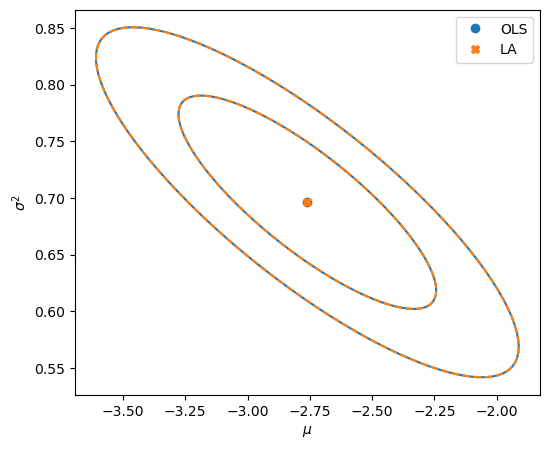

```python
# Checkpoint ols_LA_byI 0
plt.rcParams['figure.figsize'] = (6.0, 5.0)
plt.plot(ols.params[0], ols.params[1], 'o', color='C0', label="OLS");
plt.plot(LA_mode[0], LA_mode[1], 'X', color='C1', label="LA");
plt.plot(true_post['2D']['68.3'][0], true_post['2D']['68.3'][1], color='C0');
plt.plot(true_post['2D']['95.4'][0], true_post['2D']['95.4'][1], color='C0');
cr.cov_ellipse(LA_postcov, center=LA_mode, level=0.68268949, plot=plt, fmt='--', color='C1');
cr.cov_ellipse(LA_postcov, center=LA_mode, level=0.95449974, plot=plt, fmt='--', color='C1');
plt.xlabel(param_labels[0]);
plt.ylabel(param_labels[1]);
plt.legend(loc=1);
# End checkpoint
```

### Approximate Bayes Computation

Having put a lot of code in place above, we can immediately turn to choosing summary statistics and a distance function for this problem. Again, you can choose what you want here, and there are intuitive choices that work well, but the only strict requirement is that your approximation converge to the true solution.

**Record your choice of summary statistic(s) and distance function in words below.**

> choice of summary statistics and distance function

```python
# Checkpoint ols_summaries_byI 0
# Record your choice of summary statistic(s) and distance function in words above!
# End checkpoint
```

Implement these choices below.

```python
# class ABC_ols(ABC):
#    def summaries(self, data):
#        # return summary statistics as a 1D np.array
#    def distance(self, s1, s2):
#        # return scalar distance between 2 sets of summary statistics
#    def simulate(self, a, b):
#        # return simulated data, given additional parameters arguments

# YOUR CODE HERE
raise NotImplementedError()
```

Encode the priors for this problem, recalling our advice above about how to deal with excessively wide or improper priors.

```python
# priors = ...

# YOUR CODE HERE
raise NotImplementedError()
```

Let's try instatiating the `ABC_ols` class and checking that it works.

```python
abc = ABC_ols({'x':x, 'y':y}, param_names, priors)

abc.run(1)
print(abc.samples)
print(abc.distances)
print(abc.summaries(abc.simulate(*abc.samples[0])))
```

```
[[-3.89167262  0.83005895]]
[6.06190361]
[-4.70069492  0.91727442]
```

Assuming that looks acceptable, we can proceed as above by generating a large number of samples,

```python
%time abc.run(100000)
```

```
CPU times: user 10.1 s, sys: 389 ms, total: 10.5 s
Wall time: 10.1 s
```

... examining the corresponding distribution of distances,

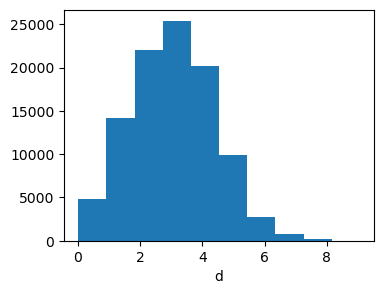

```python
abc.distance_hist();
```

... and checking whether the approximation converges to the exact solution as the distance threshold becomes more strict.

```
eps = 3.049378710459747
Acceptance rate: 0.5 ( 50000 accepted samples )
```

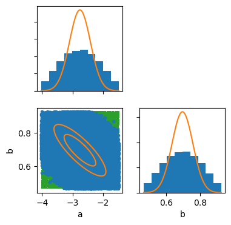

```python
eps = np.quantile(abc.distances, 0.5)
print("eps =", eps)
abc.select_distances(eps)
abc.plot_acceptances(truth=true_post, size=4.0)
```

```
eps = 1.3236199640011812
Acceptance rate: 0.1 ( 10000 accepted samples )
```

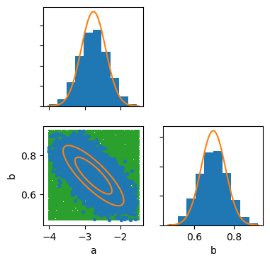

```python
eps = np.quantile(abc.distances, 0.1)
print("eps =", eps)
abc.select_distances(eps)
abc.plot_acceptances(truth=true_post, size=4.0)
```

```
eps = 0.9387952890433297
Acceptance rate: 0.05 ( 5000 accepted samples )
```

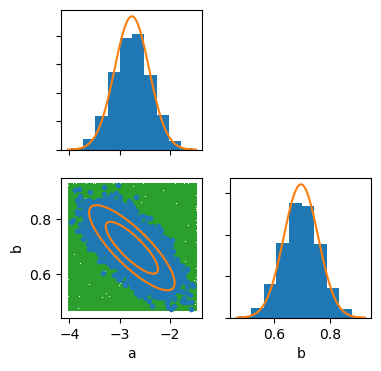

```python
eps = np.quantile(abc.distances, 0.05)
print("eps =", eps)
abc.select_distances(eps)
abc.plot_acceptances(truth=true_post, size=4.0)
```

```
eps = 0.4258089882508284
Acceptance rate: 0.01 ( 1000 accepted samples )
```

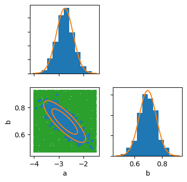

```python
eps = np.quantile(abc.distances, 0.01)
print("eps =", eps)
abc.select_distances(eps)
abc.plot_acceptances(truth=true_post, size=4.0)
```

Once you're happy with the last cell above, we can quantitatively check the approximation against the exact solution.

```python
# Checkpoint ols_ABC 1
print('Checking that we have a non-silly number of samples left...')
assert abc.samples2.shape[0] >= 100
print('Checking credible interval for a...')
ci = cr.whist_ci(cr.whist(abc.samples2[:,0]))
assert np.isclose(ci['center'][0], true_post['1D']['a'].mean(), rtol=0.1)
assert np.isclose(ci['width'][0], true_post['1D']['a'].std(), rtol=0.1)
print('Checking credible interval for b...')
ci = cr.whist_ci(cr.whist(abc.samples2[:,1]))
assert np.isclose(ci['center'][0], true_post['1D']['b'].mean(), rtol=0.1)
assert np.isclose(ci['width'][0], true_post['1D']['b'].std(), rtol=0.1)
print('Yay!')
# End checkpoint
```

```
Checking that we have a non-silly number of samples left...
Checking credible interval for a...
Checking credible interval for b...
Yay!
```

## Case: linear model with unknown scatter

Now that you have some experience with the nuts and bolts of LA and ABC, we'll apply them to a final scenario that's only slightly more complex, but doesn't have a nice, exact solution. Recall that, in OLS, the $y$ values were scattered around a linear model according to a normal distribution with a known variance of 1. Here, we will still have the same variance for every data point, but it will be a free parameter that we have to fit for. To keep things simple, we will adopt a uniform prior over the positive real line for the variance.

```python
param_names = param_names + ['s2']
```

As always, draw and write down the generative model.

> Space for the generative model

To keep things from being too boring, we will read in a second data set for which $\sigma^2 \neq 1$.

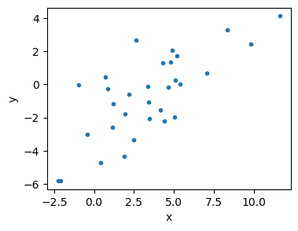

```python
table = np.loadtxt(datapath+'linescat.txt')
x = table[:,0]
y = table[:,1]

plt.rcParams['figure.figsize'] = (4.0, 3.0)
plt.plot(x, y, '.');
plt.xlabel("x"); plt.ylabel("y");
```

Unlike the previous sections, we will not begin by computing a true posterior either analytically or by MCMC. You could do the latter to have something to compare to if you really get stuck, but try to get a feel for how you would go about using the approximate methods when the usual methods are not practical. Upon grading, you will find some diagnostic plots comparing your approximations to our MCMC solutions at the end of this problem.

### Laplace Approximation

Also unlike the previous sections, you are basically on your own to perform the necessary calculations for this problem. Stick to the parameter ordering given by `param_names`, and record the LA mode and covariance in `LA_mode` and `LA_postcov`. (You can insert additional cells below rather than using just one.)

[output not shown]

[figure not shown]

```python
# LA_mode = ...
# LA_postcov = ...

# YOUR CODE HERE
raise NotImplementedError()
```

Report what you found:

```python
print("mode:", LA_mode)
print("cov:", LA_postcov)
```

```
mode: [-2.71795243  0.59450389  2.79146107]
cov: [[ 0.19354485 -0.04059384 -0.05415257]
 [-0.04059384  0.02062252  0.05781078]
 [-0.05415257  0.05781078  0.80727458]]
```

In the "with outputs" version of this notebook on the class website, you'll see a comparison of the LA with a reliable MCMC posterior. For the data used there, the LA gets close to the posterior mode, but its estimate of the covariance leaves something to be desired. Note that, for this model, we have found something of a phase change when the data set gets small enough that the scatter is tough to distinguish from zero - LA's covariance in that case suddenly becomes much larger. For bigger data sets that the one shown, the approximation, including the covariance, gets better. We've deliberately aimed in the middle for that demonstration, which is to say that you might see any of this behaviour in your own, random data sets. (It's also possible that some of this is due to the specific way the Hessian is estimated within `minimize`, and a more careful estimate of the second derivatives would do better; we haven't investigated.)

### Approximate Bayes

For ABC, as before, let's functionally redefine the range of our priors based on what you see above. You can imagine doing this based on the LA in the first place, and iterating if you see the resulting approximate posterior doesn't become tiny before hitting the edge of the prior.

The implementation is once again left to you, but do let us know what summary statistics and distance function you're using, and make use of the sequence of diagnostic plots below.

**Record your choice of summary statistic(s) and distance function in words below.**

> choice of summary statistics and distance function

```python
# Checkpoint olsscat_summaries_byI 0
# Record your choice of summary statistic(s) and distance function in words above!
# End checkpoint
```

```python
# class ABC_scat(ABC):
#     ...
# ...
# abc = ABC_scat(...
# ...

# YOUR CODE HERE
raise NotImplementedError()
```

Let's see what your ABC gives us:

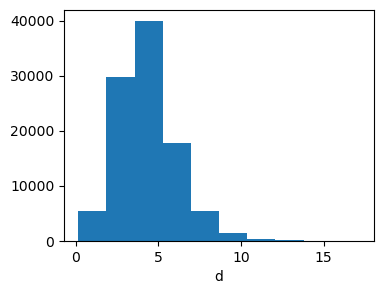

```python
abc.distance_hist();
```

```
eps = 4.144804252365463
Acceptance rate: 0.5 ( 50000 accepted samples )
```

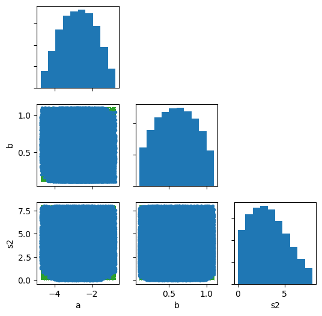

```python
eps = np.quantile(abc.distances, 0.5)
print("eps =", eps)
abc.select_distances(eps)
abc.plot_acceptances(size=6.0, show_rejects=True)
```

```
eps = 2.283464349379403
Acceptance rate: 0.1 ( 10000 accepted samples )
```

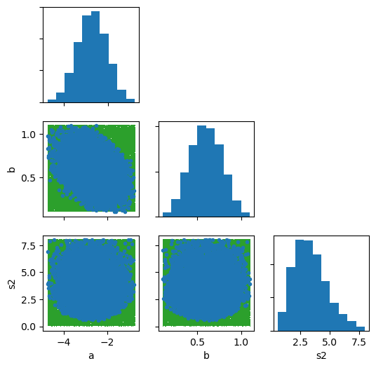

```python
eps = np.quantile(abc.distances, 0.1)
print("eps =", eps)
abc.select_distances(eps)
abc.plot_acceptances(size=6.0, show_rejects=True)
```

```
eps = 1.8121814440987376
Acceptance rate: 0.05 ( 5000 accepted samples )
```

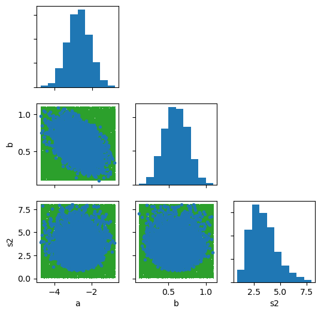

```python
eps = np.quantile(abc.distances, 0.05)
print("eps =", eps)
abc.select_distances(eps)
abc.plot_acceptances(size=6.0, show_rejects=True)
```

```
eps = 1.0750916749990063
Acceptance rate: 0.01 ( 1000 accepted samples )
```

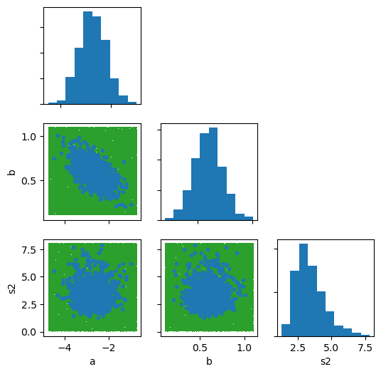

```python
eps = np.quantile(abc.distances, 0.01)
print("eps =", eps)
abc.select_distances(eps)
abc.plot_acceptances(size=6.0, show_rejects=True)
```

Hopefully you can see indications that ABC is working, although chances are you would also need to run longer and decrease the acceptance threshold even more before the comparison to the MCMC results really starts to look good. We stress that there are more intelligent, adaptive implementations of ABC than our simplistic version, which one would turn to in practice.

Below, we will compare your LA and ABC solutions (using the selection in the above cell) against our own extremely trustworthy MCMC. For the ABC, the tolerance for these tests is relatively high, reflecting the difficulty of getting a good approximation using this simple ABC method.

```python
# Tests mcmc_olsscat
```

The cell below will compare the LA (red/dashed curves) with our MCMC posterior (blue/solid curves). See the comments at the end of the LA portion of this problem.

```python
# Tests check_LA_olsscat_byI
```

Here we will overplot the MCMC posterior on the latest ABC selection.

```python
# Tests check_ABC_olsscat_byI
```

```python
# quantitative checks of the ABC convergence
# Tests test_ABC_olsscat (1 point)
```

## Parting thoughts

We hope you have gained an appreciation for and understanding of some of the approximate methods covered in the notes. Possibly, you're now more motivated to avoid using them whenever possible. Still, while a little ingenuity can go a long way in making MCMC and related methods more tractable, it's nice to know that there are approximate methods that still live in the realm of principled inference.

```python
# moar housekeeping
# Tests housekeeping2
```